# 8_multivariate_analysis

2024-12-23

## Importing libraries and setting working directory

## Importing depth profiles

Depths profiles were collected onboar R/V Pelagia with sensors mounted on rosette sampler. Parameters collected include -  
1. Salinity  
2. Temperature  
3. Pressure (used to measure Depth)  
4. Density (derived using Gibbs SeaWater equation)  
5. Conductivity  
6. Oxygen  
7. Turbidity  
8. Fluorescence

I will perform factor analysis to identify latent variables , apply dimension reduction appraoches like PCA and identify clusters to dissect spatio temporal patterns.  
## Both cruises combined  
Before factor analysis, I want to make sure its suitability. I will use Kaiser-Meyer-Olkin (KMO) index and Barlett’s test from `psych` R package.

```r
kmo_result <- KMO(ctd_profiles %>% select(-Location_Station_Number, -Location, -Station_Number, -Depth, -Pressure))
bartlett_result <- cortest.bartlett(ctd_profiles %>% select(-Location_Station_Number, -Location, -Station_Number, -Depth, - Pressure))
```

```
## R was not square, finding R from data
```

```r
print(kmo_result)
```

```
## Kaiser-Meyer-Olkin factor adequacy
## Call: KMO(r = ctd_profiles %>% select(-Location_Station_Number, -Location,
##     -Station_Number, -Depth, -Pressure))
## Overall MSA =  0.68
## MSA for each item =
##     Salinity  Temperature      Density Conductivity       Oxygen    Turbidity
##         0.35         0.60         0.94         0.60         0.96         0.70
## Fluorescence
##         0.98
```

```r
print(bartlett_result)
```

```
## $chisq
## [1] 198668
##
## $p.value
## [1] 0
##
## $df
## [1] 21
```

### *Kaiser-Meyer-Olkin (KMO) Factor Adequacy*

The Measure of Sampling Adequacy (MSA) of 0.68 in the KMO test is mediocre, but acceptable for factor analysis.  
Salinity has a low MSA of 0.35, shows weak variance with other variables. Consider removing.  
Moderate MSA were observed for temperature, conductivity, and turbidity, whereas high MSA (> 0.7) observed for density, oxygen, and fluorescence, will provide adequate to considerably towards the factor model.

### *Barlett’s test of sphericity*

A large chi sqaure value of 198,668 indicates strong correlations among variables.  
Highly significant (p = 0) indicating corraltion matrix is not an identiy matric and factor analysis is appropriate.

*Factor Analysis*

```r
fa_result <- fa(ctd_profiles %>% select(-Location_Station_Number, -Location, -Station_Number, -Depth, -Pressure, -Salinity),
                nfactors = 2, rotate = "varimax", fm = "ml")
print(fa_result)
```

```
## Factor Analysis using method =  ml
## Call: fa(r = ctd_profiles %>% select(-Location_Station_Number, -Location,
##     -Station_Number, -Depth, -Pressure, -Salinity), nfactors = 2,
##     rotate = "varimax", fm = "ml")
## Standardized loadings (pattern matrix) based upon correlation matrix
##                ML1   ML2   h2     u2 com
## Temperature  -0.83 -0.55 1.00 0.0023 1.7
## Density       0.84  0.51 0.97 0.0289 1.6
## Conductivity -0.84 -0.54 1.00 0.0034 1.7
## Oxygen        0.45  0.63 0.60 0.3966 1.8
## Turbidity     0.47  0.88 1.00 0.0050 1.5
## Fluorescence  0.22  0.35 0.17 0.8285 1.7
##
##                        ML1  ML2
## SS loadings           2.58 2.16
## Proportion Var        0.43 0.36
## Cumulative Var        0.43 0.79
## Proportion Explained  0.54 0.46
## Cumulative Proportion 0.54 1.00
##
## Mean item complexity =  1.7
## Test of the hypothesis that 2 factors are sufficient.
##
## df null model =  15  with the objective function =  13.87 with Chi Square =  151838.1
## df of  the model are 4  and the objective function was  1.92
##
## The root mean square of the residuals (RMSR) is  0.01
## The df corrected root mean square of the residuals is  0.03
##
## The harmonic n.obs is  10948 with the empirical chi square  63.92  with prob <  4.3e-13
## The total n.obs was  10948  with Likelihood Chi Square =  20989.96  with prob <  0
##
## Tucker Lewis Index of factoring reliability =  0.482
## RMSEA index =  0.692  and the 90 % confidence intervals are  0.684 0.7
## BIC =  20952.76
## Fit based upon off diagonal values = 1
## Measures of factor score adequacy
##                                                    ML1  ML2
## Correlation of (regression) scores with factors   0.99 0.99
## Multiple R square of scores with factors          0.99 0.98
## Minimum correlation of possible factor scores     0.97 0.97
```

I extracted 2 factors (ML1 and ML2) that together explain 79 % of the variance.  
The Root Mean Square Residual (RMSR) is 0.01 which indicates good fit for the model. The factors explain correlations between variables well.  
The Root Mean Square Error of Estimation (RMSEA) is 0.692 which is high. RMSEA values below < 0.1 are considerable, but given the simplicity of the data it is still useful.

Explanation of the loadings:  
1. Temperature: Strong negative loading on ML1 and moderate on ML2; high communality (well-explained by both factors); high complexity (contributes to both factors).  
2. Density: Strong positive loading on ML1 and moderate on ML2; high communality; ad high complexity.  
3. Conductivity: same as temperature.  
4. Oxygen: Moderate positive loading on ML1 and ML2; moderate communality (partially explained by the two factors); and high complexity (contributes significantly to both factors).  
5. Turbidity: Moderate loading on ML1 and high on ML2; high communality; and low complexity (primarily explained by ML2).  
6. Fluorescence: Low loadings on both ML1 and ML2; low communality. It also has high uniqueness- much of its variance is independent of these two factors. High complexity and weakly contributes to both factors.  
Temperature, density, conductivity, turbidity have high lowdings and communality inf=dicating that these variables are strngly rerpresented by the two factors.  
Oxygen moderately cntributes to both, and therfore shouuld be retained.  
Fluorescence have low communality and high uniqueness and is not well-represneted by either variables. Might not contribute significant in further analysis.

ML1 represnts phyical properties - teperature, density, conductivity.  
ML2 represets particlate and biological properties like turidity and oxygen - indicating biological activty.

I will also exclude fluorescence from further abysis.

##performing PCA i will use the original variables istead of the latent ones, just to keep the structure intact for easy interpretation. I will exclude fluorescence from further analysis.

```r
pca_data <- ctd_profiles %>%
  select(-Location_Station_Number, -Location, -Station_Number, -Depth, -Pressure, -Salinity, -Fluorescence)

pca_result <- prcomp(pca_data, scale. = TRUE)

summary(pca_result)
```

```
## Importance of components:
##                           PC1     PC2     PC3     PC4     PC5
## Standard deviation     2.0989 0.64130 0.40336 0.14332 0.01390
## Proportion of Variance 0.8811 0.08225 0.03254 0.00411 0.00004
## Cumulative Proportion  0.8811 0.96331 0.99585 0.99996 1.00000
```

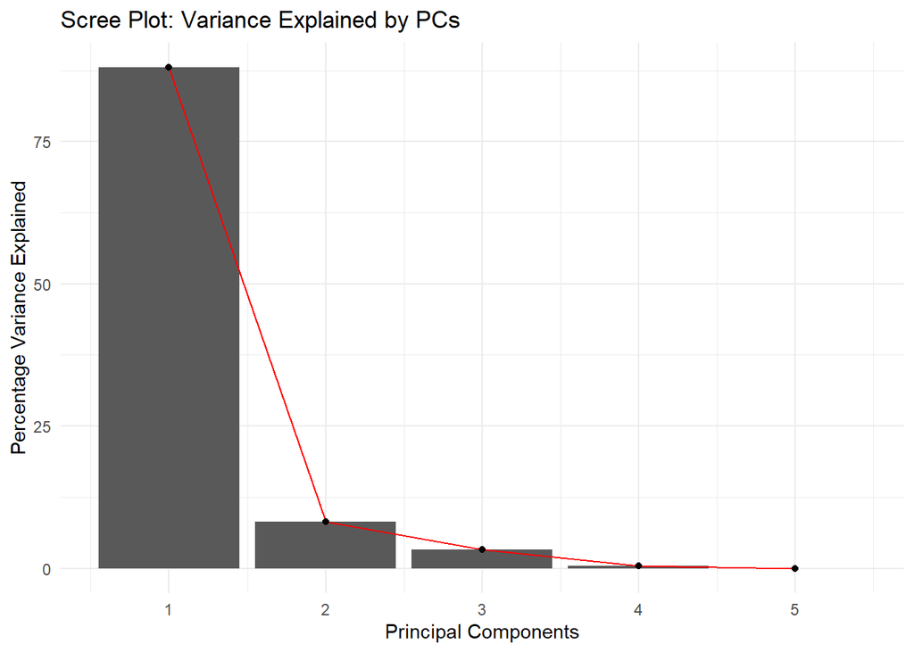

```r
pca_var <- data.frame(PC = 1:length(pca_result$sdev),
                      Variance = (pca_result$sdev^2) / sum(pca_result$sdev^2) * 100)

ggplot(pca_var, aes(x = PC, y = Variance)) +
  geom_col() +
  geom_line(aes(group = 1), color = "red") +
  geom_point() +
  labs(title = "Scree Plot: Variance Explained by PCs", x = "Principal Components", y = "Percentage Variance Explained") +
  theme_minimal()
```

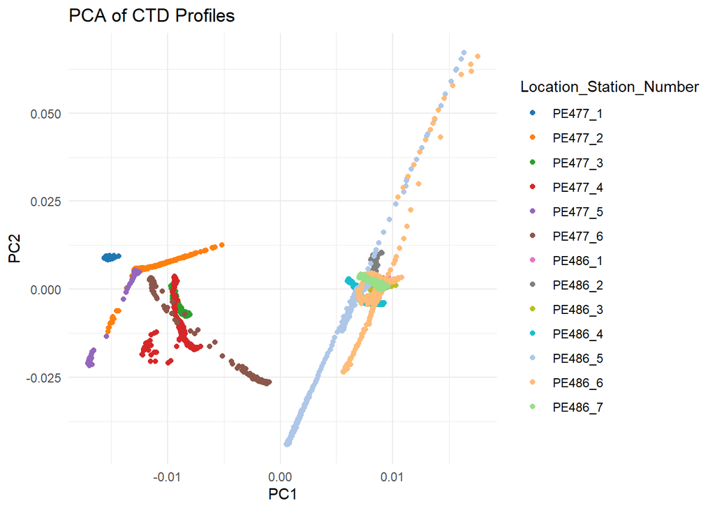

```r
unique_stations <- unique(ctd_profiles$Location_Station_Number)  # Get unique station names
custom_palette <- pal_d3("category20")(length(unique_stations))  # Generate unique colors
color_mapping <- setNames(custom_palette, unique_stations)  # Map each station to a color

autoplot(pca_result, data = ctd_profiles,  color = "Location_Station_Number") +
  theme_minimal() +
  scale_color_manual(values = color_mapping) +
  labs(title = "PCA of CTD Profiles", x = "PC1", y = "PC2")
```

PC1 explains 88.11 % of the variance- captures almost all meaningful pattersn. PC2 adds aother 8.23, bringing the total to 96.33 %  
The datset is effectively two dimensional.

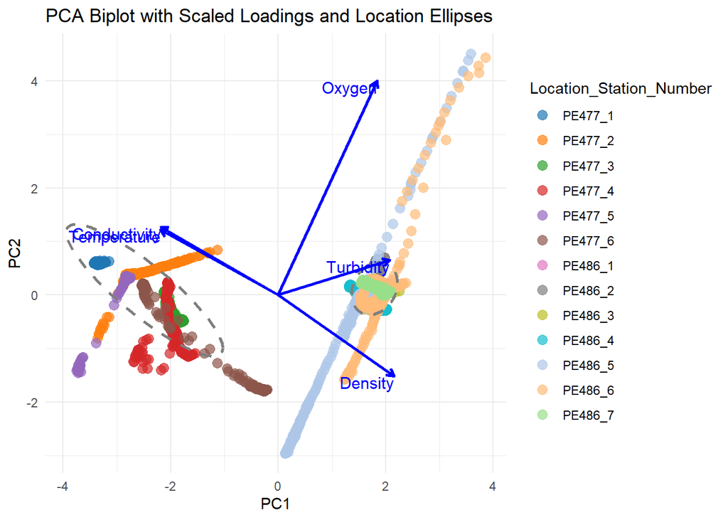

```r
# Scale loadings to a maximum absolute value of 0.1
pca_loadings <- as.data.frame(pca_result$rotation[, 1:2])  # Loadings for PC1 and PC2
pca_loadings$Variable <- rownames(pca_result$rotation)  # Add variable names

# Scale loadings
max_loading <- max(abs(pca_loadings[, 1:2]))  # Maximum absolute loading value
desired_max <- 4  # Desired maximum magnitude
pca_loadings_scaled <- pca_loadings
pca_loadings_scaled[, 1:2] <- pca_loadings_scaled[, 1:2] / max_loading * desired_max

# PCA Scores for plotting
pca_scores <- as.data.frame(pca_result$x[, 1:2])  # PCA scores (PC1 and PC2)
pca_scores$Location_Station_Number <- ctd_profiles$Location_Station_Number
try(pca_scores <- pca_scores %>%
  tidyr::separate(Location_Station_Number, into = c("Location", "Station_Number"), sep = "_", remove = F))


ggplot() +
  # Plot PCA scores
  geom_point(data = pca_scores, aes(x = PC1, y = PC2, color = Location_Station_Number), alpha = 0.7, size = 3) +
  # Add ellipses grouped by Location
  stat_ellipse(data = pca_scores, aes(x = PC1, y = PC2, group = Location, color = Location),
               linetype = "dashed", size = 1) +
  # Add loadings as arrows
  geom_segment(data = pca_loadings_scaled, aes(x = 0, y = 0, xend = PC1, yend = PC2),
               arrow = arrow(length = unit(0.2, "cm")), color = "blue", size = 1) +
  # Add variable names to loadings
  geom_text(data = pca_loadings_scaled, aes(x = PC1, y = PC2, label = Variable),
            color = "blue", vjust = 1, hjust = 1, size = 4) +
  # Labels and theme
  labs(title = "PCA Biplot with Scaled Loadings and Location Ellipses",
       x = "PC1", y = "PC2") +
  # Apply custom color palette
  scale_color_manual(values = color_mapping) +
  theme_minimal() +
  theme(legend.position = "right")
```

##Performing clustering

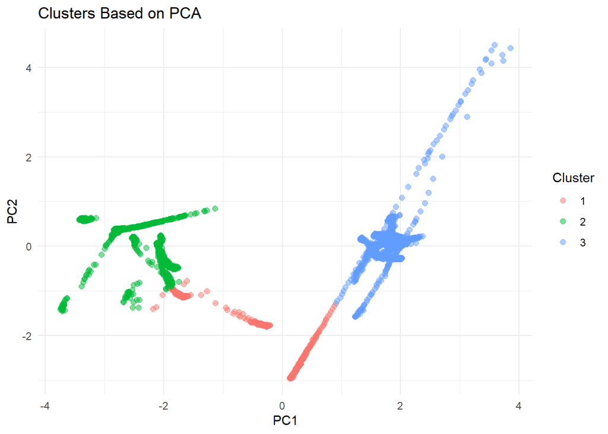

```r
pca_scores <- as.data.frame(pca_result$x[, 1:2])

# Perform k-means clustering (choose k based on elbow method or silhouette score)
set.seed(123)
kmeans_result <- kmeans(pca_scores, centers = 3)  # Adjust centers as needed
pca_scores$Cluster <- as.factor(kmeans_result$cluster)

# Add cluster assignments back to original data
ctd_profiles$Cluster <- pca_scores$Cluster

ggplot(pca_scores, aes(x = PC1, y = PC2, color = Cluster)) +
  geom_point(size = 2, alpha = 0.5) +
  labs(title = "Clusters Based on PCA", x = "PC1", y = "PC2") +
  theme_minimal()
```

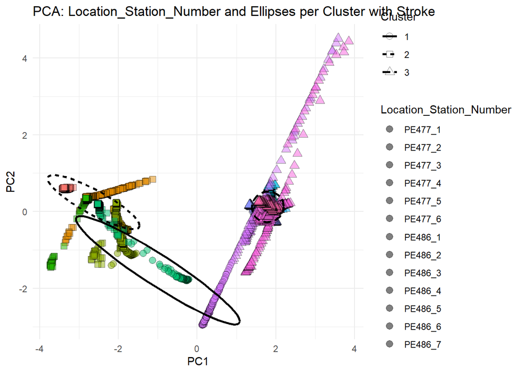

```r
# Combine PCA plot with color for Location_Station_Number and shape for Cluster
# Generate custom color palette
custom_palette <- pal_d3("category20")(16)  # Generate 16 distinct colors from the D3 palette
# Define a fixed custom palette for Location_Station_Number
custom_palette <- c(
  "PE477_1" = "#1f77b4", "PE477_2" = "#ff7f0e", "PE477_3" = "#2ca02c",
  "PE477_4" = "#d62728", "PE477_5" = "#9467bd", "PE477_6" = "#8c564b",
  "PE486_1" = "#e377c2", "PE486_2" = "#7f7f7f", "PE486_3" = "#bcbd22",
  "PE486_4" = "#17becf", "PE486_5" = "#aec7e8", "PE486_6" = "#ffbb78",
  "PE477_7" = "#98df8a", "PE486_7" = "#ff9896",
  "PE477" = lighten("#0c1844", 0.4), "PE486" = lighten("#850000", 0.4)
)

# Add Cluster column to the PCA scores dataframe
pca_scores <- as.data.frame(pca_result$x[, 1:2])
pca_scores$Cluster <- ctd_profiles$Cluster
pca_scores$Location_Station_Number <- ctd_profiles$Location_Station_Number

# PCA plot with ellipses per Cluster and stroke for points
ggplot(pca_scores, aes(x = PC1, y = PC2)) +
  geom_point(aes(fill = Location_Station_Number, shape = Cluster), color = 'black', alpha = 0.5, size = 3, stroke = 0.3) +  # Add stroke
  stat_ellipse(aes(group = Cluster, linetype = Cluster), level = 0.95, size = 1) +  # Ellipses per Cluster
  scale_color_manual(values = custom_palette) +  # Custom color palette
  labs(title = "PCA: Location_Station_Number and Ellipses per Cluster with Stroke",
       x = "PC1", y = "PC2", color = "Location/Station", shape = "Cluster") +
  theme_minimal() +
  scale_shape_manual(values = c(21, 22, 24))
```

```r
  theme(legend.position = "right")
```

[output not shown]

#Hierarchical clustering

```r
# Split Location from Location_Station_Number
distance_matrix <- dist(pca_scores, method = "euclidean")  # Adjust method if needed
```

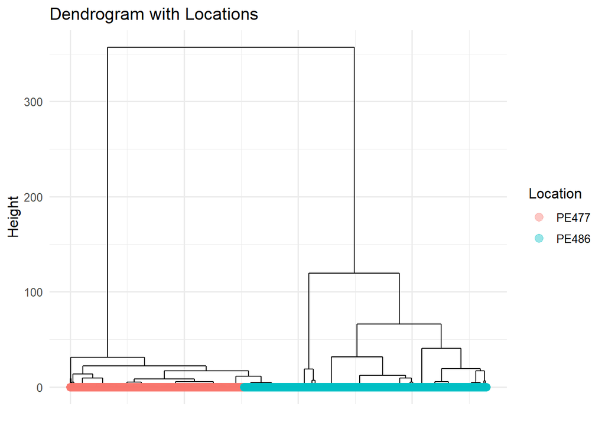

```r
# Perform hierarchical clustering
hclust_result <- hclust(distance_matrix, method = "ward.D2")  # Use Ward's method

# Cut tree into clusters (choose the number of clusters, e.g., 3)
pca_scores$Cluster <- as.factor(cutree(hclust_result, k = 3))  # Adjust 'k' for number of clusters

# Add cluster assignments back to original data
ctd_profiles$Cluster <- pca_scores$Cluster
ctd_profiles$Location <- sub("_.*", "", ctd_profiles$Location_Station_Number)

# Create a dendrogram object
dendrogram <- as.dendrogram(hclust_result)

# Convert the dendrogram to a ggplot-friendly format
library(ggdendro)
dendro_data <- dendro_data(dendrogram)

# Add geom points to the dendrogram tips colored by Location
ggplot() +
  geom_segment(data = dendro_data$segments,
               aes(x = x, y = y, xend = xend, yend = yend), size = 0.5) +
  geom_point(data = dendro_data$labels,
             aes(x = x, y = 0, color = ctd_profiles$Location), size = 3, alpha = 0.4) +
  labs(title = "Dendrogram with Locations",
       x = "", y = "Height", color = "Location") +
  theme_minimal(base_size = 12) +
  theme(axis.text.x = element_blank(),
        axis.ticks.x = element_blank(),
        legend.position = "right")
```

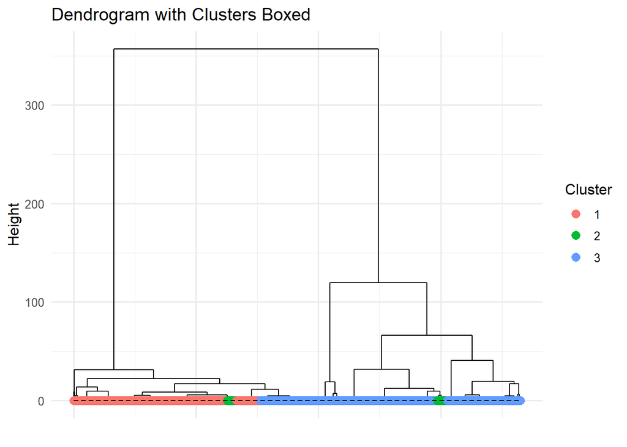

```r
# need to check the dendrogram for cluster gaian. i think there is some issue with the #assignment of lcusters wrt to stations.
# Create a mapping of cluster assignment from PCA scores
dendro_data$labels$Cluster <- pca_scores$Cluster

# Plot the dendrogram
ggplot() +
  # Add dendrogram branches
  geom_segment(data = dendro_data$segments,
               aes(x = x, y = y, xend = xend, yend = yend), size = 0.5) +
  # Add colored points to the dendrogram tips based on clusters
  geom_point(data = dendro_data$labels,
             aes(x = x, y = 0, color = Cluster), size = 3) +
  # Add rectangles around clusters based on Cluster information
  geom_rect(data = dendro_data$labels,
            aes(xmin = min(x), xmax = max(x), ymin = 0, ymax = max(y)),
            fill = NA, color = "black", linetype = "dashed", size = 0.5) +
  labs(title = "Dendrogram with Clusters Boxed",
       x = "", y = "Height", color = "Cluster") +
  theme_minimal(base_size = 12) +
  theme(axis.text.x = element_blank(),
        axis.ticks.x = element_blank(),
        legend.position = "right")
```